# Lab3

Drew Shives

9/22/2021

```r
library("tidyverse")
```

1. Create five samples of 25 observations from a normal distribution with mean 200, and standard deviation 100. Compute the mean of each sample, and plot the means in a graph using ggplot2.

```r
samples_matrix <- matrix(nrow = 5, ncol = 25)

for(i in 1:5) {
  samples_matrix[, 1:25] <- rnorm(n = 25, mean = 200, sd = 100)
}

data <- tibble(
  Index = 1:5,
  Means  = rowMeans(samples_matrix)
  )

samples_matrix
```

```
##           [,1]      [,2]     [,3]      [,4]     [,5]      [,6]      [,7]
## [1,]  55.67189  75.74583 199.0074 223.40705 154.9033  55.67189  75.74583
## [2,] 201.57107 151.50715 201.9809  86.42798 205.8038 201.57107 151.50715
## [3,]  43.39322  94.23306 155.2346 208.64258 258.8713  43.39322  94.23306
## [4,] 422.69986 186.45109 357.1072 180.35277 160.1603 422.69986 186.45109
## [5,] 276.78357  53.86265 136.1611 132.77100 253.7636 276.78357  53.86265
##          [,8]      [,9]    [,10]     [,11]     [,12]    [,13]     [,14]
## [1,] 199.0074 223.40705 154.9033  55.67189  75.74583 199.0074 223.40705
## [2,] 201.9809  86.42798 205.8038 201.57107 151.50715 201.9809  86.42798
## [3,] 155.2346 208.64258 258.8713  43.39322  94.23306 155.2346 208.64258
## [4,] 357.1072 180.35277 160.1603 422.69986 186.45109 357.1072 180.35277
## [5,] 136.1611 132.77100 253.7636 276.78357  53.86265 136.1611 132.77100
##         [,15]     [,16]     [,17]    [,18]     [,19]    [,20]     [,21]
## [1,] 154.9033  55.67189  75.74583 199.0074 223.40705 154.9033  55.67189
## [2,] 205.8038 201.57107 151.50715 201.9809  86.42798 205.8038 201.57107
## [3,] 258.8713  43.39322  94.23306 155.2346 208.64258 258.8713  43.39322
## [4,] 160.1603 422.69986 186.45109 357.1072 180.35277 160.1603 422.69986
## [5,] 253.7636 276.78357  53.86265 136.1611 132.77100 253.7636 276.78357
##          [,22]    [,23]     [,24]    [,25]
## [1,]  75.74583 199.0074 223.40705 154.9033
## [2,] 151.50715 201.9809  86.42798 205.8038
## [3,]  94.23306 155.2346 208.64258 258.8713
## [4,] 186.45109 357.1072 180.35277 160.1603
## [5,]  53.86265 136.1611 132.77100 253.7636
```

```r
data
```

```
## # A tibble: 5 × 2
##   Index Means
##   <int> <dbl>
## 1     1  142.
## 2     2  169.
## 3     3  152.
## 4     4  261.
## 5     5  171.
```

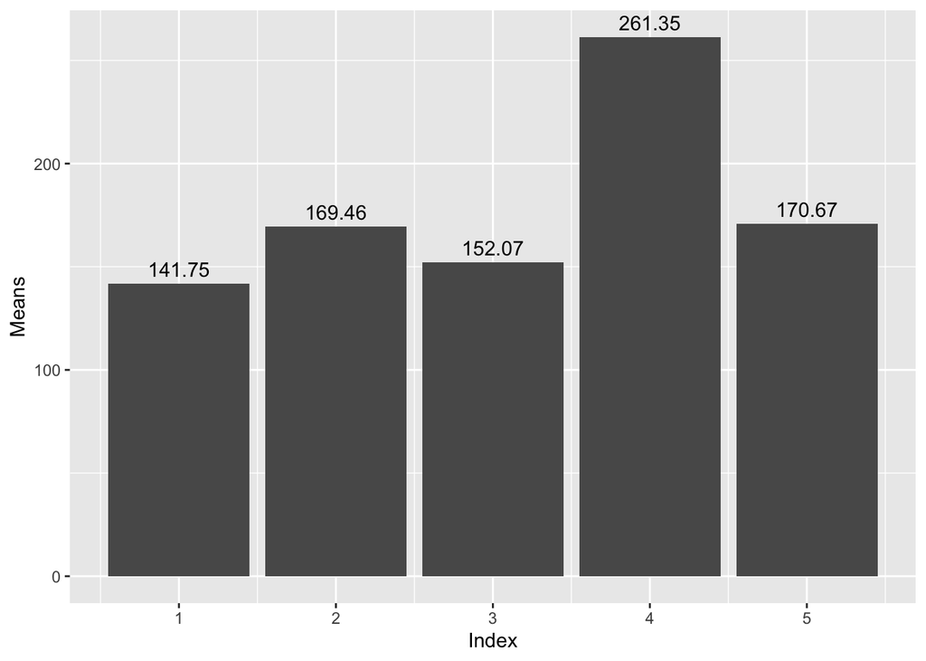

```r
ggplot(data = data, mapping = aes(x = Index, y = Means)) +
  geom_col() +
  geom_text(mapping = aes(label = sprintf("%1.2f", Means), vjust = -0.5)
  )
```

2. Additionally calculate the standard deviation of each sample from above. Use the standard deviations for error bars, and produce another graph with the means along with error bars using ggplot2.

```r
standard_deviation <- c()

for(i in 1:5) {
  standard_deviation[i] <- sqrt(sum((samples_matrix[i,] - mean(samples_matrix[i,])) ^ 2) / length(samples_matrix[i,]))
}

data <- add_column(.data = data, Std_Dev = standard_deviation, .after = "Means")

data
```

```
## # A tibble: 5 × 3
##   Index Means Std_Dev
##   <int> <dbl>   <dbl>
## 1     1  142.    66.2
## 2     2  169.    46.1
## 3     3  152.    77.2
## 4     4  261.   107.
## 5     5  171.    83.0
```

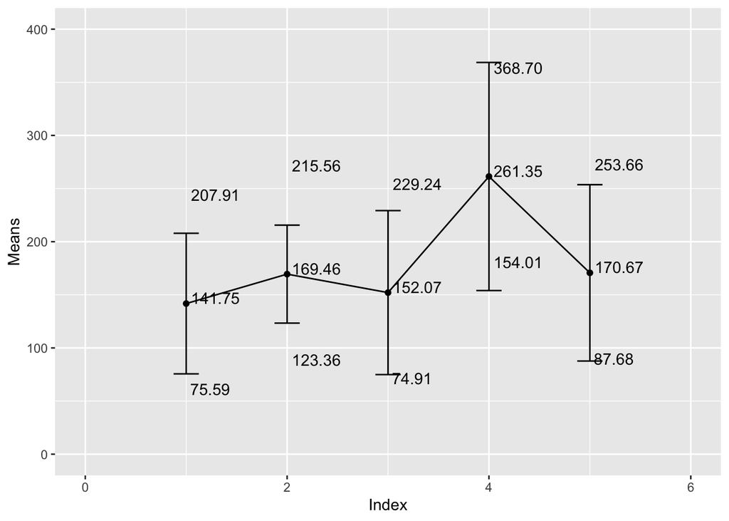

```r
ggplot(data = data, mapping = aes(x = Index, y = Means)) +
  geom_point() +
  geom_line() +
  geom_errorbar(mapping = aes(ymin = Means - Std_Dev,
                              ymax = Means + Std_Dev),
                width = 0.25) +
  geom_text(mapping = aes(label = sprintf("%1.2f", Means)), vjust = 0, hjust = -0.1) +
  geom_text(mapping = aes(label = sprintf("%1.2f", Means - Std_Dev)), vjust = 8, hjust = -0.1) +
  geom_text(mapping = aes(label = sprintf("%1.2f", Means + Std_Dev)), vjust = -9, hjust = -0.1) +
  ylim(0, 400) +
  xlim(0, 6)
```

3. Demonstrate that the sample mean across a range of n, is an unbiased estimator of the population mean using a monte-carlo simulation.
- The population is a normal distribution with mean = 10, standard deviation = 5.

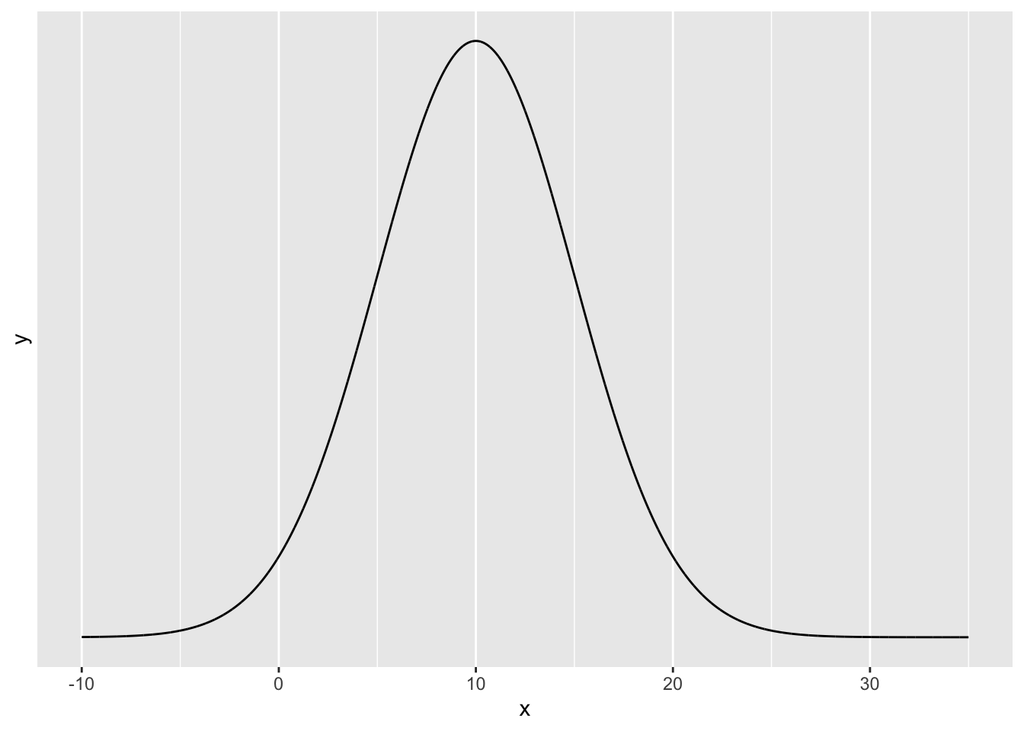

```r
population_ <- ggplot(data = tibble(x = c(-10, 35)), aes(x))+
  stat_function(fun = dnorm, n = 10000, args = list(mean = 10, sd = 5)) +
  scale_y_continuous(breaks = NULL)

population_
```

- Test a variety of n (sample size), including n = 2, 5, 10, 50, and 100

```r
n_sizes <- c(2, 5, 10, 50, 100)

n_sizes
```

```
## [1]   2   5  10  50 100
```

- For each sample size n, your task is to draw 10,000 samples of that size, then for each sample, calculate the sample mean. If the mean is unbiased, then we expect that “on average” the sample means will be the same as the population mean. To determine if this is true, compute the mean of the sample means that you produce to see if it is close to the population mean.

I had originally misinterpreted the question and sampled 10,000 samples n times (two 10,000 samples, five 10,000 samples, etc.). The first code chunk for each of the following bullets represents that. The second code chunks are for 10,000 samples of n times (10,000 samples of n = 2, 10,000 samples of n = 5, etc.).

```r
matrices_list = list()
total_data = data.frame()

for(i in 1:length(n_sizes)) {
  sample_matrix <- matrix(nrow = n_sizes[i], ncol = 10000)
  for(j in 1:nrow(sample_matrix)) {
    sample_matrix[j,] <- rnorm(n = 10000, mean = 10, sd = 5)
  }
  matrices_list[[i]] <-sample_matrix
}

for(i in 1:length(matrices_list)) {
  samples_ <- data.frame(
    matrix(unlist(matrices_list[[i]]),
           nrow = length(matrices_list[[i]][, 1]),
           byrow = TRUE
           )
      )
  samples_ <- as_tibble(samples_)
  samples_ <- add_column(.data = samples_, group = i, .before = "X1")
  samples_ <- add_column(.data = samples_, n = 1:nrow(samples_), .after = "group")
  samples_ <- add_column(.data = samples_, n_size = toString(length(matrices_list[[i]][, 1])), .after = "n")
  total_data <- rbind(total_data, samples_)
}

grouped_data <- total_data %>%
  mutate(n_means = rowMeans(
    select(total_data, c(X1:X10000))
  )) %>%
  group_by(n_size) %>%
  summarise(mean = mean(n_means)) %>%
  slice(match(n_sizes, n_size))

grouped_data
```

```
## # A tibble: 5 × 2
##   n_size  mean
##   <chr>  <dbl>
## 1 2       9.98
## 2 5      10.0
## 3 10     10.0
## 4 50     10.0
## 5 100    10.0
```

```r
samples_vector2 <- c()
samples_matrix2 <- matrix()
samples_2 <- data.frame()
samples_tibble2 <- data.frame()


for(i in n_sizes) {
  samples_vector2 <- replicate(10000, rnorm(i, 10, 5))
  samples_2 <- as_tibble(samples_vector2)
  samples_2 <- add_column(.data = samples_2, group = toString(i), .before = "V1")
  samples_2 <- add_column(.data = samples_2, n = 1:nrow(samples_2), .after = "group")
  samples_tibble2 <- rbind(samples_tibble2, samples_2)

}
gathered_data2 <- samples_tibble2 %>%
  gather(sample_group, samples, -group, -n) %>%
  arrange(group)

grouped_data2 <- gathered_data2 %>%
  group_by(group, sample_group) %>%
  summarise(
    mean = mean(samples),
    var = var(samples)
    )
means_data2 <- gathered_data2 %>%
  group_by(group) %>%
  summarise(
    group_mean = sum(samples) / length(group)
  ) %>%
  slice(match(n_sizes, group))

means_data2
```

```
## # A tibble: 5 × 2
##   group group_mean
##   <chr>      <dbl>
## 1 2           10.0
## 2 5           10.0
## 3 10          10.0
## 4 50          10.0
## 5 100         10.0
```

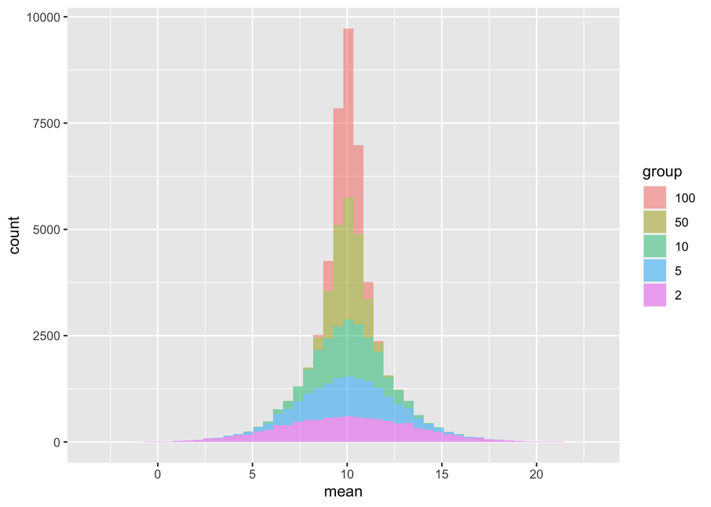

```r
grouped_data2$group <- factor(grouped_data2$group, levels = c(100, 50, 10, 5, 2))
grouped_data2 %>%
  ggplot(mapping = aes(x = mean, fill = group)) +
  geom_histogram(bins = 50, alpha = 0.5)
```

- Show the mean of the sample means for each sample size.

```r
grouped_data
```

```
## # A tibble: 5 × 2
##   n_size  mean
##   <chr>  <dbl>
## 1 2       9.98
## 2 5      10.0
## 3 10     10.0
## 4 50     10.0
## 5 100    10.0
```

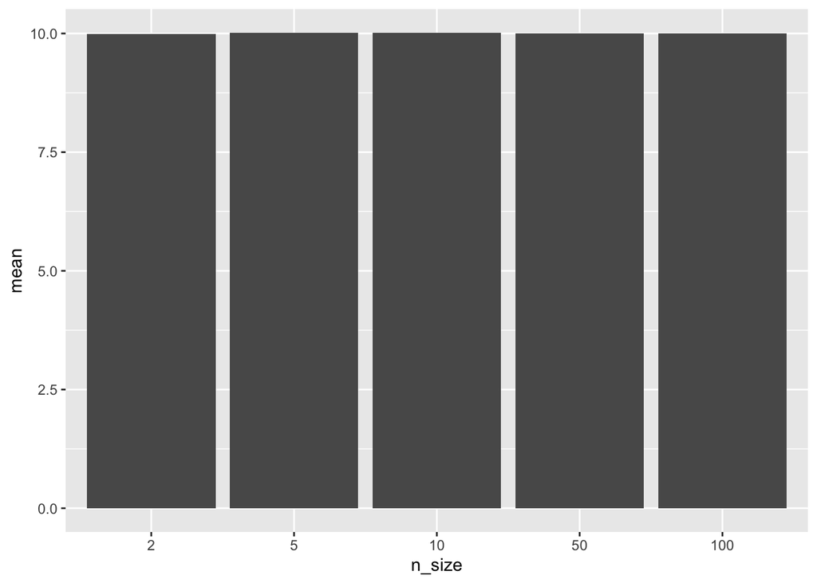

```r
ggplot(data = grouped_data, mapping = aes(x = factor(n_size, n_sizes), y = mean)) +
  geom_col() +
  labs(x = "n_size")
```

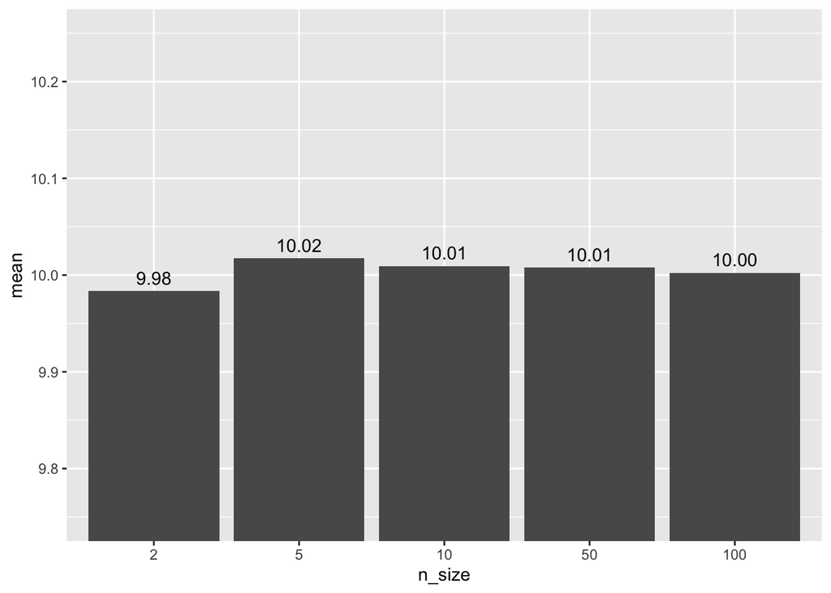

```r
ggplot(data = grouped_data, mapping = aes(x = factor(n_size, n_sizes), y = mean)) +
  geom_col() +
  labs(x = "n_size") +
  coord_cartesian(ylim = c(9.75, 10.25)) +
  geom_text(mapping = aes(label = sprintf("%1.2f", mean)), vjust = -0.5)
```

```r
means_data2
```

```
## # A tibble: 5 × 2
##   group group_mean
##   <chr>      <dbl>
## 1 2           10.0
## 2 5           10.0
## 3 10          10.0
## 4 50          10.0
## 5 100         10.0
```

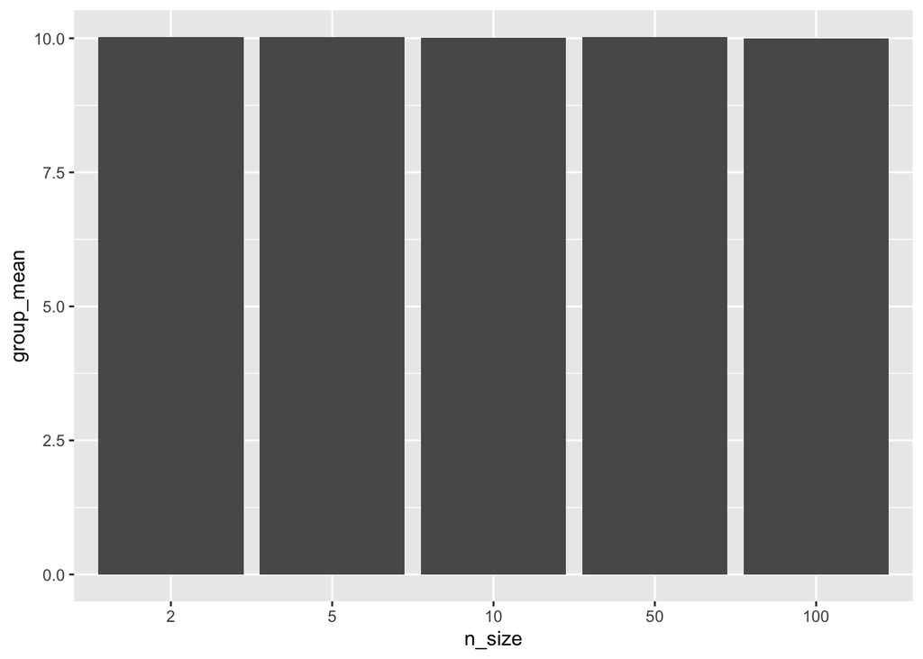

```r
ggplot(data = means_data2, mapping = aes(x = factor(group, n_sizes), y = group_mean)) +
  geom_col() +
  labs(x = "n_size")
```

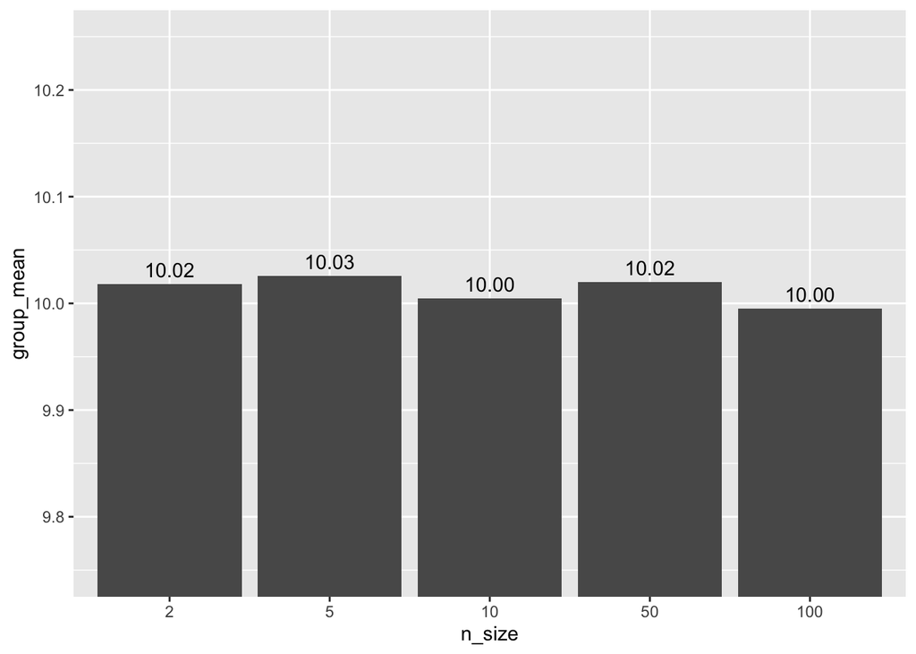

```r
ggplot(data = means_data2, mapping = aes(x = factor(group, n_sizes), y = group_mean)) +
  geom_col() +
  labs(x = "n_size") +
  coord_cartesian(ylim = c(9.75, 10.25)) +
  geom_text(mapping = aes(label = sprintf("%1.2f", group_mean)), vjust = -0.5)
```

4. Use a monte carlo simulation to compare the standard deviation formulas (divide by N vs N-1), and show that the N-1 formula is a better unbiased estimate of the population standard deviation, especially for small n.
- Use the same normal distribution and samples sizes from above.
- Rather than computing the mean for each sample, compute both forms of the standard deviation formula, including the sample standard deviation that divides by N-1, and the regular standard deviation that divides by N.
- You should have 10,000 samples for each sample size, and 10,000 standard deviations for each the sample and regular standard deviation. Your task is to find the average of each, for each sample-size.

```r
var_sd_data <- total_data %>%
  mutate(row_means = rowMeans(
    select(total_data, c(X1:X10000))
  ), .after = "n_size") %>%
  mutate(row_var_pop = (rowSums((
    select(total_data, c(X1:X10000)) - row_means) ^ 2) / 10000
  ), .after = "row_means") %>%
  mutate(row_var_sample = apply(total_data, 1, var), .after = "row_var_pop") %>%
  group_by(n_size) %>%
  summarise(mean_var_pop = mean(row_var_pop),
            mean_var_sample = mean(row_var_sample),
            mean_std_dev_pop = sqrt(mean_var_pop),
            mean_std_dev_sample = sqrt(mean_var_sample)) %>%
  slice(match(n_sizes, n_size))

var_sd_data
```

```
## # A tibble: 5 × 5
##   n_size mean_var_pop mean_var_sample mean_std_dev_pop mean_std_dev_sample
##   <chr>         <dbl>           <dbl>            <dbl>               <dbl>
## 1 2              25.1            25.2             5.01                5.01
## 2 5              24.8            24.8             4.98                4.98
## 3 10             25.0            25.0             5.00                5.00
## 4 50             25.1            25.3             5.01                5.03
## 5 100            25.0            26.0             5.00                5.10
```

```r
var_sd_data2 <- gathered_data2 %>%
  group_by(group) %>%
  summarise(
    group_mean = sum(samples) / length(group),
    group_sample_var = var(samples),
    group_sample_std_dev = sqrt(group_sample_var),
    group_pop_var = sum((samples - group_mean) ^ 2) / length(group),
    group_pop_std_dev = sqrt(group_pop_var)
  ) %>%
  slice(match(n_sizes, group))

var_sd_data2
```

```
## # A tibble: 5 × 6
##   group group_mean group_sample_var group_sample_std_dev group_pop_var
##   <chr>      <dbl>            <dbl>                <dbl>         <dbl>
## 1 2           10.0             24.9                 4.99          24.9
## 2 5           10.0             24.8                 4.98          24.8
## 3 10          10.0             25.0                 5.00          25.0
## 4 50          10.0             25.0                 5.00          25.0
## 5 100         10.0             25.0                 5.00          25.0
## # … with 1 more variable: group_pop_std_dev <dbl>
```

- Which of the standard deviations is more systematically biased? That is, which one is systematically worse at estimating the population standard deviation?

I was able to solve all problems with minimal help (Stack Overflow for some syntactical stuff).